# Introduction to Numpy & Pandas

## Python Libraries

- [Built-in Functions](https://docs.python.org/3/library/functions.html)
- [The Python Standard Library](https://docs.python.org/3/library/index.html)

Python have some built-in functions which we had seen some before. Yet, these functions are the very basic of Python programming. You can download Youtube videos, access Twitter API, make GPU analysis for Big Data, create games or web pages, built robots, and so on.

Python also have its Standard Library like `math`, `os`, `sys`, `random`, `time`... But most enjoyful applications created with Python are created with `other` libraries.

- [20 Python libraries you can’t live without](https://pythontips.com/2013/07/30/20-python-libraries-you-cant-live-without/)
- [20 Great Python Libraries You Must Know](http://blog.stoneriverelearning.com/20-great-python-libraries-you-must-know/)

Also check out [100 Numpy Exercises](https://github.com/rougier/numpy-100/blob/master/100%20Numpy%20exercises%20with%20hint.ipynb) and [Solutions](https://github.com/rougier/numpy-100/blob/master/100%20Numpy%20exercises.ipynb).

We will cover the two basic external libraries: Numpy & Pandas. They are irreplaceable libraries of Python especially for Data Science.

Downlaod this notebook to make practice.

## Numpy

NumPy has strong integration with other Python libraries. It looks like small brother of pandas in a way :). Let's call him:

```python
import numpy as np
```

Arrays are similar to the lists but are more flexible.

```python
stock_list = [3.5, 5, 2, 8, 4.2]
```

```python
returns = np.array(stock_list)
print('List: ', stock_list)
print('Array: ', returns)
print(returns.shape)
print(type(returns))
```

```
List:  [3.5, 5, 2, 8, 4.2]
Array:  [ 3.5  5.   2.   8.   4.2]
(5,)
<class 'numpy.ndarray'>
```

Be careful about the notation:

```python
np.array(1,2,3,4)    # WRONG
```

```
---------------------------------------------------------------------------
ValueError                                Traceback (most recent call last)
<ipython-input-4-9aa09435aea3> in <module>()
----> 1 np.array(1,2,3,4)    # WRONG

ValueError: only 2 non-keyword arguments accepted
```

```python
np.array([1,2,3,4])  # RIGHT
```

```
array([1, 2, 3, 4])
```

We can create two dimensinal array by:

```python
A = np.array([[1, 2], [3, 4]])
print(A)
print(A.shape)
print(type(A))
```

```
[[1 2]
 [3 4]]
(2, 2)
<class 'numpy.ndarray'>
```

Arrays are indexed in much the same way as lists in Python. Elements of a list begin indexing from $0$ and end at $n−1$ , where $n$ is the length of the array.

```python
print(returns[0], returns[len(returns) - 1])
```

```
3.5 4.2
```

```python
print(returns[1:3])
```

```
[ 5.  2.]
```

```python
print(A[:, 0])
```

```
[1 3]
```

```python
print(A[0, :])
```

```
[1 2]
```

Passing only one index to a 2-dimensional array will result in returning the row with the given index as well, providing us with another way to access individual rows.

```python
print(type(A[0,:]))
```

```
<class 'numpy.ndarray'>
```

Accessing the index of an individual element will return only the element.

```python
print(A[1, 1])
```

```
4
```

#### Complex Numbers:

```python
c = np.array( [ [1,2], [3,4] ], dtype=complex )
print(c)
```

```
[[ 1.+0.j  2.+0.j]
 [ 3.+0.j  4.+0.j]]
```

### Array Functions

```python
print(np.log(returns))
```

```
[ 1.25276297  1.60943791  0.69314718  2.07944154  1.43508453]
```

```python
print(np.mean(returns))
```

```
4.54
```

```python
print(np.max(returns))
```

```
8.0
```

```python
print(np.min(returns))
```

```
2.0
```

```python
print(np.exp(returns))
```

```
[   33.11545196   148.4131591      7.3890561   2980.95798704    66.68633104]
```

```python
print(np.sqrt(returns))
```

```
[ 1.87082869  2.23606798  1.41421356  2.82842712  2.04939015]
```

Further Reading: [Universal Functions](https://docs.scipy.org/doc/numpy/user/quickstart.html#universal-functions)

You can do the very basic math operations to the numpy arrays:

```python
print(returns * 0)
```

```
[ 0.  0.  0.  0.  0.]
```

```python
print(returns * 2)
```

```
[  7.   10.    4.   16.    8.4]
```

```python
print(returns * 2 + 10)
```

```
[ 17.   20.   14.   26.   18.4]
```

```python
print("Mean: ", np.mean(returns),' --- ', "Std Dev: ", np.std(returns))
```

```
Mean:  4.54  ---  Std Dev:  1.99158228552
```

```python
N = 10
assets = np.zeros((N, 100))
returns = np.zeros((N, 100))
```

This function, `zeroes()`, creates a NumPy array with the given dimensions that is entirely filled in with $0$ . We can pass a single value or a tuple of as many dimensions as we like. Passing in the tuple `(N, 100)`, will return a two-dimensional array with $N$ rows and $100$ columns. Our result is a $N \times 100$ array.

You can create a matrix with 1's instead of 0:

```python
N = 10
assets = np.ones((N, 100))
returns = np.ones((N, 100))
```

Alternative of range function. It is better integrated with numpy functions:

```python
print(np.arange(6))
```

```
[0 1 2 3 4 5]
```

You can create `ranges` with `shapes`:

```python
print(np.arange(12).reshape(4,3))
```

```
[[ 0  1  2]
 [ 3  4  5]
 [ 6  7  8]
 [ 9 10 11]]
```

```python
print(np.arange(24).reshape(2,3,4))
```

```
[[[ 0  1  2  3]
  [ 4  5  6  7]
  [ 8  9 10 11]]

 [[12 13 14 15]
  [16 17 18 19]
  [20 21 22 23]]]
```

You can `reshape` the dimensions with `reshape(x,y,z,...)`:

```python
arr = np.arange(12).reshape(4,3)
print(arr)
```

```
[[ 0  1  2]
 [ 3  4  5]
 [ 6  7  8]
 [ 9 10 11]]
```

```python
print(arr.reshape(12,1))
```

```
[[ 0]
 [ 1]
 [ 2]
 [ 3]
 [ 4]
 [ 5]
 [ 6]
 [ 7]
 [ 8]
 [ 9]
 [10]
 [11]]
```

```python
print(arr.reshape(1,12))
```

```
[[ 0  1  2  3  4  5  6  7  8  9 10 11]]
```

You will have error if you use impossible shapes:

```python
print(arr.reshape(1,4))
```

```
---------------------------------------------------------------------------
ValueError                                Traceback (most recent call last)
<ipython-input-32-0f3a5b9b5b3e> in <module>()
----> 1 print(arr.reshape(1,4))

ValueError: cannot reshape array of size 12 into shape (1,4)
```

```python
print(arr.reshape(1,13))
```

```
---------------------------------------------------------------------------
ValueError                                Traceback (most recent call last)
<ipython-input-33-9bdbaa0929fc> in <module>()
----> 1 print(arr.reshape(1,13))

ValueError: cannot reshape array of size 12 into shape (1,13)
```

Random values with shape:

```python
r_arr = np.random.random((2,2))
print(r_arr)
```

```
[[ 0.02636317  0.49639583]
 [ 0.88345342  0.61187671]]
```

Save you values:

```python
np.savetxt('test.txt', r_arr, delimiter=',')
```

You can save the variables as objects instead:

```python
np.save('f.npy', r_arr)
```

Then load it again:

```python
loaded = np.load('f.npy')
print(loaded)
```

```
[[ 0.02636317  0.49639583]
 [ 0.88345342  0.61187671]]
```

### NaN values

```python
print(np.nan)
```

```
nan
```

```python
v = np.array([1, 2, np.nan, 4, 5])
print(v)
```

```
[  1.   2.  nan   4.   5.]
```

```python
print(np.isnan(v))
```

```
[False False  True False False]
```

```python
print(np.mean(v))
```

```
nan
```

Solution:

```python
ix = ~np.isnan(v) # the ~ indicates a logical not, inverting the bools
print(np.mean(v[ix])) # We can also just write v = v[~np.isnan(v)]
```

```
3.0
```

Or:

```python
np.nanmean(v)
```

```
3.0
```

## Matrix Operations

### Dot/Scalar Product

Unlike in many matrix languages, the product operator `*` operates elementwise in NumPy arrays. The matrix product can be performed using the `dot` function or method:

```python
A = np.array( [[1,1],[0,1]] )
B = np.array( [[2,0],[3,4]] )
```

```python
A * B
```

```
array([[2, 0],
       [0, 4]])
```

```python
A.dot(B)
```

```
array([[5, 4],
       [3, 4]])
```

```python
B.dot(A)
```

```
array([[2, 2],
       [3, 7]])
```

Or:

```python
np.dot(A,B)
```

```
array([[5, 4],
       [3, 4]])
```

### Cross Product

```python
np.cross(A,B)
```

```
array([-2, -3])
```

## Exercise - Linearization

```python
# data is created with:
# np.savetxt('data.txt', np.log(10*np.random.random(1000)))
```

Download the data.txt

```python
non_linear = np.loadtxt('data.txt')
```

```python
import matplotlib.pyplot as plt
```

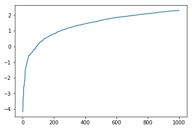

```python
non_linear = np.sort(non_linear)
plt.plot(non_linear)
plt.show()
```

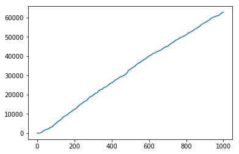

```python
plt.plot(np.square(4+non_linear)*np.square(4+non_linear)*np.square(4+non_linear))
plt.show()
```

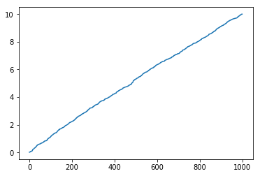

```python
plt.plot(np.exp(non_linear))
plt.show()
```

## Resouces

- https://www.quantopian.com/lectures/introduction-to-numpy
- https://docs.scipy.org/doc/numpy/user/quickstart.html#universal-functions
- https://docs.scipy.org/doc/numpy/user/index.html
- https://www.datacamp.com/community/tutorials/python-numpy-tutorial